# Guía de Creación objetos y Funciones

Diplomado en Data Science UC

Curso de Herramientas Computacionales

# Comandos de control

## If

El comando `if` lo ocupamos cuando queremos agregar una condición, la estructura es que realizará la sentencia 1 si cumple la condición 1. Si no se cumple la condicion, no hará nada.

```r
if("condición 1"){
  "sentencia 1"
}
```

Pero se pueden agregar mas condiciones si es que no cumple con la condición 1 con el comando `if else` donde con la misma escructura que el anterior, puedo incluir una condición 2 y si se cumple ejecutar la sentencia 2.

```r
if("condicion 1"){
  "sentencia 1"
}else if("condicion 2"){
  "sentencia 2"
}
```

Luego si no quiero agregar una nueva condición, pero quiero incluir una sentencia para los casos en que no se cumplan las condiciones anteriores puedo ocupar el comando `else`, donde solo es necesario incluir la sentencia 3.

```r
if("condicion 1"){
  "sentencia 1"
}else if("condicion 2"){
  "sentencia 2"
}else{
  "sentencia 3"
}
```

Un ejemplo practico de muchos if concatenados es el siguiente:

```r
x = 43
if(x < 20){
  y = x*2
}else if(x%%2 == 0){
  y = x^2
}else{
  y = 10
}
y
```

```
## [1] 10
```

> En este caso como como x = 43, no cumple con la primera condición así que pasa al siguiente, como el modulo en base dos no es igual a cero (es un número impar) tampoco cumple con la condición y como no cumplio con las anteriores, el `y` toma el valor de 10.

Si hacemos lo mismo pero ahora con x = 18:

```r
x = 18
if(x < 20){
  y = x*2
}else if(x%%2 == 0){
  y = x^2
}else{
  y = 10
}
y
```

```
## [1] 36
```

> Como el x es menor a 20, entra en la primera condicion e `y` vale 18*2 = 36, luego x si es un número par algunos pensarian que también entra a la segunda condición, pero al ser un `else if` si entra a una condición anterior no puede entrar a la siguiente.

Un comando muy utilizado es el `ifelse` ya que es una abreviación de lo anterior, pero que también recibe vectores de datos. Si cumple cierta condición, realiza la primera sentencia. Si lo no la cumple, entonces cumple la segunda sentencia. Podría inducir a un nuevo ifelse encadenado.

```r
ifelse("condición", "sentencia 1", "sentencia 2")
```

Por ejemplo si tenemos un vector con caracteres y queremos asignarles números, es bastante comodo ocupar esta función.

```r
x = c("alto", "bajo", "bajo", "alto")
y = ifelse(x == "alto", 1, 0)
y
```

```
## [1] 1 0 0 1
```

> Las observaciones que antes indican “alto” ahora son un 1 y todos los demás 0.

## For

El comando `for` lo que hace es que para una variable (flotante) ejecutará una sentencia que yo defina las veces que el objeto iterable me lo diga. Tiene la siguinte escructura:

```r
for("variable" in "objeto iterable"){
  ejecuta sentencia
}
```

Una forma clasica de ocupar este comando es sobre posiciones de objetos, es por esto, es que en este ejemplo se define un vector vacio **x** el cual se irá completando en cada secuencia del for. Como vemos será la variable **i** que se mueve entre los números 1 a 15, y en cada suceción *i* guardamos el elemento **2i +3** en la posición **i** del vector **x**.

```r
x = c()
for (i in 1:15) {
  x[i] = 2*i + 3
}
```

Luego el vector x tiene guardado todos los elementos creados en cada secuencia.

```
##  [1]  5  7  9 11 13 15 17 19 21 23 25 27 29 31 33
```

Otra forma común de ocupar los `for` es que la variable **i** se mueva dentro de un vector completo de `strings` y que en cada iteración ejecute una sentencia definida.

```r
Nombre = c("Javiera", "Freddy", "Diego", "Felipe", "Nicolas", "Camila")
for (i in Nombre) {
  print(paste("Mi nombre es:",i))
}
```

```
## [1] "Mi nombre es: Javiera"
## [1] "Mi nombre es: Freddy"
## [1] "Mi nombre es: Diego"
## [1] "Mi nombre es: Felipe"
## [1] "Mi nombre es: Nicolas"
## [1] "Mi nombre es: Camila"
```

## While

El comando `while` es muy útil cuando quiero generar valores o elementos que cumplan cierta condición, ya que no se detiene de hacer una sentencia hasta que la condición deje de ser cumplida.

```r
while("contición") {
  "Sentencia"
}
```

Una forma de ocupar un while, es que al valor inicial de **n** que es 0, se sumará un número aleatorio entre 0 e 1 **hasta** que **n** sea mayor de 2.

```r
n = 0
while (n < 2){
  n = n + runif(1, min = 0, max = 1)
  print(n)
}
```

```
## [1] 0.325734
## [1] 1.216578
## [1] 2.13889
```

Como vemos, no paro de generar elementos hasta que **n** ya no cumpliera con la condición.

### Ejercicio: Juego de dados.

Sea un juego el cual cada jugador tiene la posibilidad de lazar Y veces un dado de 6 caras y se cuenten la proporción de 6 en la totalidad de sus turnos. El juegador ganador sería el que tuvo una proporcion de 6 mas alta.

Programemos un juego con 4 jugadores y 5 lanzamientos para cada jugador.

> Ojo: esta es una forma de programar este juego. Hay muchas mas!!

> Iremos paso a paso! por eso se colocará una semilla para que siempre nos muestre los mismos números.

```r
set.seed(122)
for(i in 1:4){ #Recorremos a cada jugador
  resultado = floor(runif(5, min = 1, max = 7)) # Los resultados de sus 5 lanzamientos
  print(resultado)
}
```

```
## [1] 6 6 2 1 4
## [1] 4 5 1 1 4
## [1] 6 3 4 4 4
## [1] 1 1 4 3 2
```

> La funcion `runif` me permite crear números aleatorios en cierto intervalo, pero como solo queremos los números enteros, le aplicamos la función `floor` que me entrega el número entero menor.

Ahora que ya tenemos los resultados de cada juego, queremos contar cuantos 6 hay para cada jugador, así que crearemos un contador que aumente en 1 cada vez que un jugador tenga un 6.

```r
set.seed(122)
contador = rep(0,4) # Contador, empieza para todos los jugadores con un 0
for(i in 1:4){
  resultado = floor(runif(5, min = 1, max = 7))

  for (j in resultado){ #creamos un nuevo for que recorra los resultados para cada jugador
    if(j == 6){ # si el resultado es igual a 6, que sume un 1 al jugador i
      contador[i] = contador[i] + 1
    }
  }
}
contador
```

```
## [1] 2 0 1 0
```

> Creamos un `for` dentro de un `for`, esto significa que dentro de la iteracion 2 del primer for, el segundo debé terminar todas sus iteraciones antes de pasar a la iteración 3 del primero.

Como vemos por el contador, el primer jugador fue el que gano el juego ya que es el que tiene mas cantidad de 6 en sus turnos. Pero queremos que identifique al ganador. Por eso ocuparemos la función `which` que muestra la posición de elemento que cumple con la condición que se señale.

```r
set.seed(122)
contador = rep(0,4) # Contador, empieza para todos los jugadores con un 0
for(i in 1:4){
  resultado = floor(runif(5, min = 1, max = 7))

  for (j in resultado){ #creamos un nuevo for que recorra los resultados para cada jugador
    if(j == 6){ # si el resultado es igual a 6, que sume un 1 al jugador i
      contador[i] = contador[i] + 1
    }
  }
}
propocion = contador/5 # proporcion de 6 para cada jugador
ganador = which(propocion == max(propocion))
# Eligo la posicion del que tenga mayor proporcion de 6

cat("El ganador es el jugador:",
        ganador, "con una proporcion de",
        max(propocion)*100,
        "% de 6")
```

```
## El ganador es el jugador: 1 con una proporcion de 40 % de 6
```

¿ Que pasa si dos jugadores tienen la misma proporción de 6? Bueno podemos suponer que es un empate y que ambos ganan, así que tambien podemos dejar registrado esa opción por si acaso.

```r
set.seed(122)
contador = rep(0,4) # Contador, empieza para todos los jugadores con un 0
for(i in 1:4){
  resultado = floor(runif(5, min = 1, max = 7))

  for (j in resultado){ #creamos un nuevo for que recorra los resultados para cada jugador
    if(j == 6){ # si el resultado es igual a 6, que sume un 1 al jugador i
      contador[i] = contador[i] + 1
    }
  }
}
propocion = contador/5 # proporcion de 6 para cada jugador
ganador = which(propocion == max(propocion))
# Eligo la posicion del que tenga mayor proporcion de 6

if(length(ganador) == 1){ #Si es un ganador, significa que el vector ganador solo tiene largo 1
    cat("El ganador es el jugador:",
        ganador, "con una proporcion de",
        max(propocion)*100,
        "% de 6")
  }else{ # Si tiene largo mayor a 1, entonces hay mas ganadores
    cat("Los ganadores son los jugadores:",
        ganador,"con una proporcion de",
        max(propocion)*100,
        "% de 6")
  }
```

```
## El ganador es el jugador: 1 con una proporcion de 40 % de 6
```

### Ejercicio: Teorema del Limite central

El Teorema del limite central me dice que si tengo un conjuntos de datos de $x_1 , x_2, ..., x_n$ con la misma distribución y $E(X) = \mu$ y $Var(X) = \sigma^2$. Entonces tengo que:

$$\bar{X} \sim Normal \left( \mu, \frac{\sigma^2}{n} \right)$$
Ahora mostraremos por simulación el Teorema del Limite Central, para esto simularemos 400 muestras de 100 observaciones, donde cada muestra distrubuye Exponencial($\lambda = 0.5$), por lo tanto, cada muestra tendría una $E(X) = 2$ y $Var(X) = 4$ por el comportamiendo de la distribución Exponencial.

Con estas características deberíamos llegar a que el promedio se comporta como:
$$\bar{X} \sim Normal \left( 2, \frac{4}{100} \right)$$

Ahora una muestra de 100 elementos de una Exponencial($\lambda = 0.5$) se vería así:

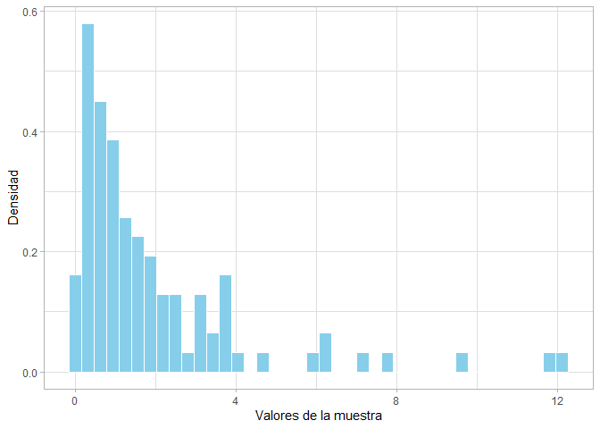

```r
set.seed(122)
m = rexp(100, rate = 0.5)
ggplot(data = NULL) +
  aes(x = m) +
  geom_histogram( aes(y =..density..),
                  bins = 40, color = "white", fill = "skyblue" ) +
  theme_light() +
  xlab("Valores de la muestra") +
  ylab("Densidad")
```

> Los datos tienen un comportaminedo según una distribución exponencial.

Ahora generaremos 400 muestras con un `for` donde en cada iteración guardaremos el promedio de estas muestras.

```r
set.seed(123)
promedios = c()
for (i in 1:400) {
  muestra = rexp(100, rate = 0.5)
  promedios[i] = mean(muestra)
}

c(mean(promedios), var(promedios))
```

```
## [1] 2.00476451 0.03581195
```

Vemos que la media de los promedios es igual a 2 y que la varianza de los datos es de 0.035 que es bastante cercano a 0.04.

Ahora si vemos el comportamiento gráficamente, vemos que los promedios son bastante normales y que efectivamente se parecen mucho a la normal que nos dice el Teorema.

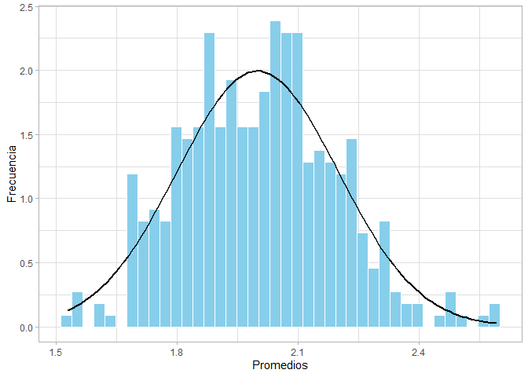

```r
ggplot(data = NULL) +
  aes(x = promedios) +
  geom_histogram( aes(y =..density..),
                  bins = 40, color = "white", fill = "skyblue" ) +
  stat_function(fun = dnorm,
                args = list(mean = 2,
                            sd = 0.2), lwd = 1) +
  theme_light() +
  xlab("Promedios") +
  ylab("Frecuencia")
```

Ahora si generamos mas muestras esto tenderá aún mas a una normal. Se deja al gusto del lector seguir probando con mas muestras o otras distribuciones.

## Funciones

En ejemplo del juego anterior programamos como sería un juego con un dado, especificamente para 4 juegadores lanzando el dado 5 veces, pero ahora si queremos repetir el juego pero para un jugador extra tendríamos que anotar todo de nuevo. Es por ello que cuando queramos repetir un procedimiento que sabremos que ocuparemos de nuevo para otros datos, es bueno dejado registrado en una función.

La estructura es la siguiente:

```r
Nombre <- function("argumento1", "argumento2", "argumento3"){
  "secuencia"
  return("elemento")
}
```

> Nombre es el nombre de la función que ocuparemos cada vez que queremos ejecutar la función. Los argumentos son los elementos que cambiaremos cada vez que la ocupemos, pueden ser todos los que quieran. La secuencia es el procedimiento que hará la función cada vez que la utilicemos. Podemos retornar cierto elemento del proceso con la función `return`.

Ahora por ejemplo, podemos volver a la programación que hicimos del juego, pero generar una función que reciba por argumento el número de jugadores y el número de lanzamientos.

```r
JUEGO <- function(x, y){
  # x: número de jugadores
  # y: número de lanzamientos
  contador = rep(0, x)
  for(i in 1:x){
  resultado = floor(runif(y, min = 1, max = 7))

  for (j in resultado){
    if(j == 6){
      contador[i] = contador[i] + 1
      }
    }
  }
  propocion = contador/y
  ganador = which(propocion == max(propocion))
  if(length(ganador) == 1){
    cat("El ganador es el jugador:",
        ganador, "con una proporcion de",
        max(propocion)*100,
        "% de 6")
    }else{
    cat("Los ganadores son los jugadores:",
        ganador,"con una proporcion de",
        max(propocion)*100,
        "% de 6")
    }
}

set.seed(2)
JUEGO(5,5)
```

```
## Los ganadores son los jugadores: 2 4 con una proporcion de 40 % de 6
```

Entonces ahora cada vez que queramos simular un juego nuevo solo debemos aplicar la función `JUEGO` y señar los jugadores y lanzamientos.

### Ejercicio: Resumen de datos.

Muchas veces cuando estamos en la etapa exploratoria de los datos queremos extraer información de las variables y creamos el mismo resumen para todas una y otra vez. Es por esto, que podemos programar un resumen a nuestro gusto con la información que nosotros queramos.

Para este ejercicio ocuparemos la base de datos ya ocupada en el curso de la Encuesta Nacional de Salud.

```r
library(readxl)
ENS <- read_excel("Encuesta nacional de salud.xlsx")
```

Ahora, en este caso estudiaremos ciertos indicadores de una variable continua con respecto a una variable categórica. Para ejemplificar ocuparemos el PESO segun el SEXO.

```r
ENS %>%
  group_by(Sexo) %>%
  summarise(Promedio = mean(Peso),
            desviacion = sd(Peso),
            Total = n(),
            Prop = Total/3251*100)
```

```
## # A tibble: 2 x 5
##   Sexo   Promedio desviacion Total  Prop
##   <chr>     <dbl>      <dbl> <int> <dbl>
## 1 Hombre     75.8       13.1  1471  45.2
## 2 Mujer      66.5       13.3  1780  54.8
```

> Aca calculamos el promedio y desviacion del peso según el sexo. Además de calcular la proporción de hombres y mujeres.

> Estos son algunos de los indices que me interesan.

Ahora podemos ver esta relación gráficamente, donde lo mas adecuado por la naturaleza de los datos sería un boxplot.

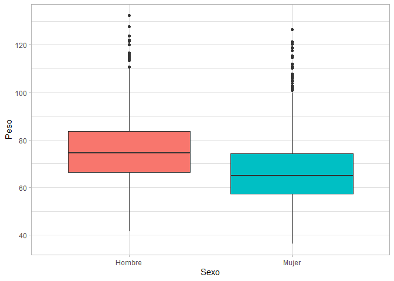

```r
ggplot(ENS) +
    aes(x = as.factor(Sexo), y = Peso, fill = as.factor(Sexo)) +
    geom_boxplot() +
    xlab("Sexo") +
    ylab("Peso") +
    theme_light() +
    guides(fill = FALSE)
```

> La función `guides` me permite modificar la leyenda, en este caso indicar si tendrá o no una leyenda según fill.

Ahora esto que hemos programado para las variables PESO según SEXO queremos automatizarlo en una función.

Cosas que debemos tener en cuenta:

- La variables al ingresar podrían contener NA es por eso que incluiremos un argumento que por defecto será igual a `TRUE` que elimine los NA al hacer los cálculos.
- En los argumentos escribiremos los nombres de las funciones “entre comillas”, es decir, en formato string. Para obtener o trabajar con la variable sin ser string ocupamos la función `get`, que obtiene el objeto original al hacer cualquier operación.

```r
Resumen <- function(var1, var2,  base, omit.na = TRUE){

  if(omit.na){
    base = na.omit(base)
  }

  n <- dim(base)[1]

  tabla <- base %>%
    group_by(get(var2)) %>%
    summarise(Promedio = mean(get(var1)),
              desviacion = sd(get(var1)),
              Total = n(),
              Prop = Total/n*100)
  names(tabla)[1] <- var2

  g <- ggplot(base) +
    aes(x = as.factor(get(var2)), y = get(var1), fill = as.factor(get(var2))) +
    geom_boxplot() +
    xlab(var2) +
    ylab(var1) +
    theme_light() +
    guides(fill = FALSE)

  print(g)
  return(tabla)
}
```

Ahora que ya creamos la función, veamos que pasa cuando quiero hacer un resumen del IMC según DIABETES.

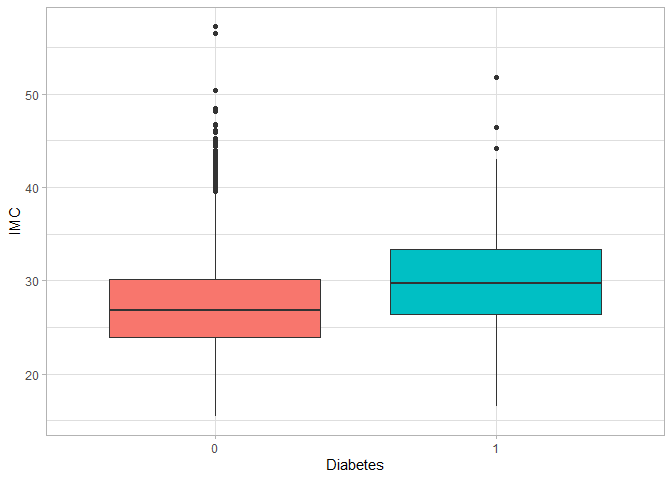

```
## # A tibble: 2 x 5
##   Diabetes Promedio desviacion Total  Prop
##      <dbl>    <dbl>      <dbl> <int> <dbl>
## 1        0     27.4       4.95  2895  89.4
## 2        1     30.0       5.07   343  10.6
```

```r
Resumen("IMC", "Diabetes", ENS)
```

Como ven, ahora podría hacer un resumen estadístico para cualquier variable continua según una categoría. Esta idea podemos generalizar para cualquier varible o resumen estadístico necesario, se deja al gusto del lector si quiere generar nuevas funciones de utilidad.